# How much woodland would offset UK carbon emissions

```r
library(tidyverse)
```

```r
library(sf)       # for mapping
library(ggsvg)    # for using svg icons in ggplot2
```

## Estimating how much woodland would offset UK carbon emissions

**Annual carbon emissions (2019):** 774 million tonnes CO2 equivalent

(Source: [Department for Environment, Food & Rural Affairs, UK Government](https://www.gov.uk/government/statistics/uks-carbon-footprint/carbon-footprint-for-the-uk-and-england-to-2019))

**Area of the UK:** 230154570471 m<sup>2</sup> = 23015457 hectares (Source:[Office for National Statistics](https://geoportal.statistics.gov.uk/datasets/ons::countries-december-2021-gb-buc/explore?location=49.003829%2C1.290710%2C5.17))

**How much CO<sub>2</sub> does woodland sequester each year?**

*Estimated area of UK forest (2019):*3.19 million hectares (Source:[Forest Research](https://www.forestresearch.gov.uk/tools-and-resources/statistics/forestry-statistics/forestry-statistics-2019/woodland-area-and-planting-5/))

*Estimated CO<sub>2</sub> sequestered per annum by UK forests (2020):* 20.5 million tonnes CO<sub>2</sub>e pa (Source:[Forest Research](https://www.forestresearch.gov.uk/tools-and-resources/statistics/forestry-statistics/forestry-statistics-2018/uk-forests-and-climate-change-5/carbon-sequestration/))

So we can calculate *estimated CO<sub>2</sub> sequestered per annum per hectare:* 6.426332 tonnes CO<sub>2</sub>e pa.

But there is a lot of uncertainty around this. See, for example, ‘On average, one hectare of native broadleaf woodland will store 300 - 350 tonnes of carbon over a 100-year period.’. This works out as 3.25 tonnes CO<sub>2</sub>e pa per hectare (*Source:* [The Woodland Trust](https://www.woodlandtrust.org.uk/plant-trees/woodland-carbon-farmers-and-landowners/)).

Using the data above, we can estimate

```r
# area of woodland required to offset UK emissions (hectares)
area_to_offset <- 774 * 1e6 / 6.426332

# proportion of the UK (as woodland) required to offset UK emissions
prop_uk <- area_to_offset / (230154570471 * 0.0001)
```

## Producing the visualisation

### 1. Read in geospatial files

*Source:* [ONS Geoportal Countries](https://geoportal.statistics.gov.uk/datasets/ons::countries-december-2021-gb-buc/explore?location=49.003829%2C1.290710%2C5.17)

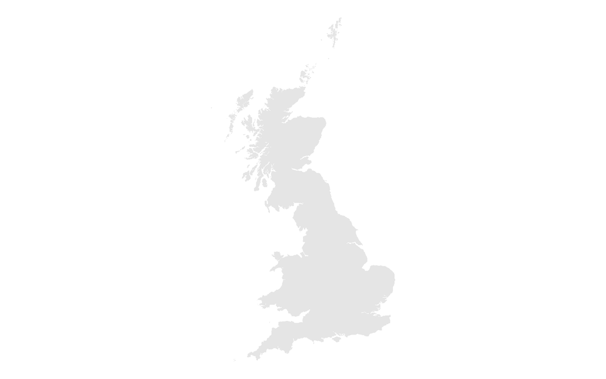

```r
# read in shapefile for Great Britain
uk_outline <- read_sf("../data/Countries_(December_2021)_GB_BUC/CTRY_DEC_2021_GB_BUC.shp") %>%
  st_union() # merge polygons to give an outline

# check everything looks as expected
ggplot(uk_outline) +
  geom_sf(colour=NA) +
  theme_void()
```

```r
# check area of UK
st_area(uk_outline)
```

```
## 230154570471 [m^2]
```

## 2. Create a grid

See [sf docs](https://r-spatial.github.io/sf/reference/st_make_grid.html).

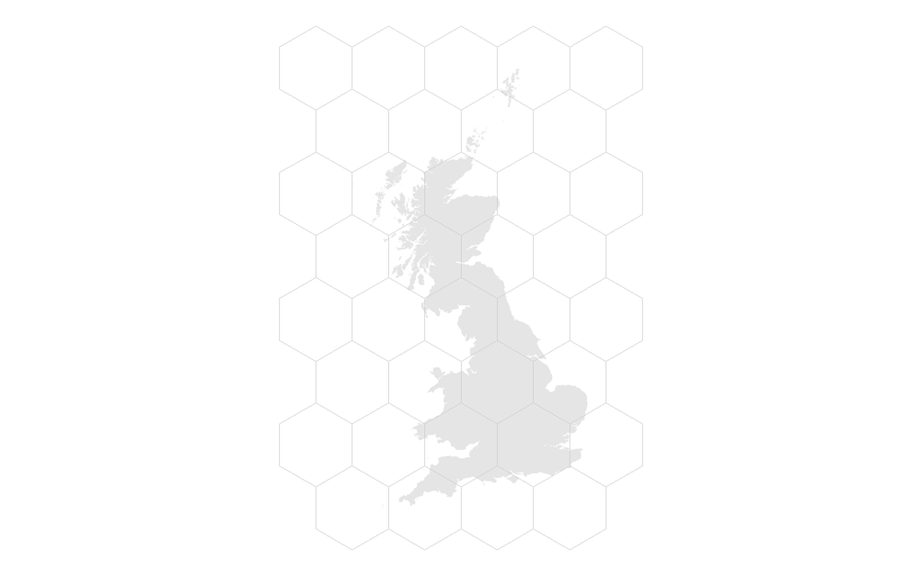

```r
# cell_size <- 40000  # for final image
cell_size <- 200000   # for testing (make code quicker to run)

# create a hexagonal grid
grid <- st_make_grid(uk_outline,
                     square = FALSE,
                     cellsize = cell_size) %>%
  as.data.frame() %>%
  #slice_sample(n = 10) %>%
  st_as_sf()

# check what the grid looks like
ggplot() +
  geom_sf(data = uk_outline, colour=NA) +
  geom_sf(data = grid, alpha = 0, colour = "grey80") +
  theme_void()
```

# 3. Experiment with grid

I experimented with: - randomly placing trees within grid cells - random colour variations - Using different svg icons for trees

```r
num_trees_per_cell <- 1

cell_touches_outline <- function(cell){

  cell_touches <- cell %>%
    st_intersects(uk_outline, sparse = FALSE)

      # extract logical from matrix
  cell_touches[1,1]
}

cell_touches_outline(grid[1])
```

```
## [1] FALSE
```

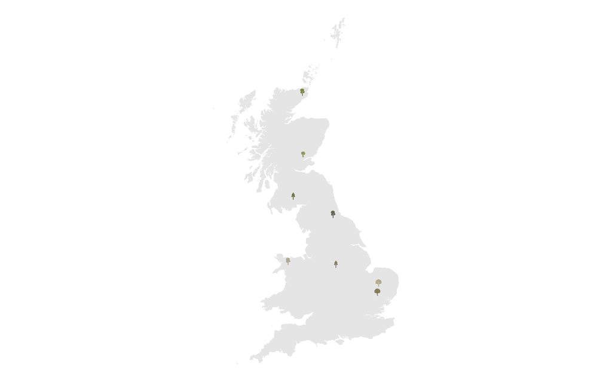

```r
# identify grid cells which touch the UK
grids_UK <- grid %>%
  as.data.frame() %>%
  mutate(cell_touches = map_lgl(geometry, ~cell_touches_outline(.x))) %>%
  filter(cell_touches) %>%
  st_as_sf()

num_cells <- nrow(grids_UK)

# generate a random point within each grid cell
random_points_in_grid_cells <- st_sample(grids_UK,
                                         size = rep(num_trees_per_cell,
                                                    num_cells)) %>%
                              st_as_sf()



# convert to (x,y) coordinates so can use geom_point (rather than geom_sf)
point_coord <- random_points_in_grid_cells %>%

  st_filter(uk_outline[1]) %>%
  st_coordinates() %>%
  as_data_frame()
# fill="#73BC9B" stroke-color="#73BC9B" fill-opacity="0.5" stroke-opacity="0.8"

# -----------------------------------------------------------------------------
# svg tree icons as text strings
# -----------------------------------------------------------------------------

# create an svg to plotted at the centre of each grid hexagon
tree1_txt <- '<?xml version="1.0" encoding="UTF-8"?>
<svg width="128pt" height="128pt" version="1.1" viewBox="0 0 128 128" xmlns="http://www.w3.org/2000/svg">
 <g class="tree" id="tree1">
  <path d="m33.176 77.25c2.207 5.8359 12.145 7.6602 17.449 2.793 1.2031 9.6133 16.406 11.16 20.156 2.3633 6.293 6.1953 18.863 4.0117 23.98-4.4648 11.09 1.3281 18.73-6.3711 15.391-16.039 7.0898-6.0742 7.168-17.996-0.9375-23.188 4.3789-9.0469-4.3867-20.066-13.371-17.059-0.72266-11.395-8.3984-16.48-19.484-14.008-5-9.8281-17.031-8.8125-22.301-0.11328-11.199-3.7109-22.527 3.0312-22.438 14.266-8.9609-1.6523-15.656 8.8125-9.9336 16.246-8.582 2.4531-11.336 13.156-5.3008 19.492-8.0273 13.262 3.5977 24.848 16.789 19.711z"/>
  <path d="m60.059 38.68 6.1992 2.8281 1.5703 17.77 7.7891-6.6484-1.1719-16.301 1.0469-0.074219 2.582 14.141 9.2383-8.0078 3.5898-0.14844-1.9844 2.1367 14.703-0.9375-1.2695 1.3125-15.383 1.7227-10.25 11.039 17.551 7.0195 0.59766 2.2461-21.27-5.9023-4.9766 5.3594 6.6172 62.156h-18.324l2.2617-68.832-3.8281-5.5195-20.18-7.875-0.59766-1.8711 17.34 4.7969-11.578-16.691 2.8633-0.23438 6.9609 8.0195 0.27344-9.207 0.91016-0.16016 1.1875 12.246 6.875 8.3516z"/>
 </g>
</svg>
'

tree2_txt <- '<?xml version="1.0" encoding="UTF-8"?>
<svg width="100pt" height="100pt" version="1.1" viewBox="0 0 100 100" xmlns="http://www.w3.org/2000/svg">
 <g class="tree">
  <path d="m53.004 52.027c2.6914 2.9297 9.8594 8.7969 17.945-0.53125 0 0 14.07-6.6211 3.4141-15.508 0 0 2.8477-8.375-4.293-7.1836 0 0-0.035156-21.164-20.191-13.297 0 0-7.2656-7.5156-14.891 1.207 0 0-10.57-1.0703-11.07 10.488 0 0-4.9609 7.9492-0.20312 16 0 0-2.4453 11.035 8.3711 8.9258 0 0 4.6562 2.4648 12.867-2.3047 5.3477-3.1055 5.7539 2.3711 8.0508 2.207z"/>
  <path d="m55.082 61.758v-6.4258c-0.9375-0.66016-1.8008-1.418-2.582-2.2305-0.10547-0.015624-0.20703-0.042968-0.30859-0.070312-1.3516-0.40625-1.9766-1.7383-3.0039-2.5586-0.38281-0.30469-0.77344-0.48828-1.2656-0.5-0.8125-0.023437-1.7266 0.40625-2.4102 0.80469-1.1484 0.66797-2.375 1.2812-3.6484 1.7812v9.2031c0.17578 8.7344-2.6445 23.078-3.4531 25.742h20.133c-0.80859-2.6602-3.6289-17.004-3.4531-25.742z"/>
 </g>
</svg>'

tree3_txt <-  '<?xml version="1.0" encoding="UTF-8"?>
<svg width="100pt" height="100pt" version="1.1" viewBox="0 0 100 100" xmlns="http://www.w3.org/2000/svg">
 <g class="tree">
  <path d="m28.906 51.207-5.3945 7.7148h22.855l2.9023-30.051h1.2539l2.8984 30.051h23.066l-5.3984-7.7148h3.5625l-5.4023-7.7188h3.5625l-5.6367-8.0586h3.8008l-5.6328-8.0625h3.7969l-19.145-27.367-19.141 27.367h3.8008l-5.6367 8.0625h3.8008l-5.6367 8.0586h3.5625l-5.3984 7.7188z"/>
  <path d="m49.895 29.43-6.8086 70.57h13.621z"/>
 </g>
</svg>'

tree4_txt <-  '<?xml version="1.0" encoding="UTF-8"?>
<svg width="100pt" height="100pt" version="1.1" viewBox="0 0 100 100" xmlns="http://www.w3.org/2000/svg">
 <g class="tree">
  <path d="m50.57 22.016-6.2109 77.984h12.426z"/>
  <path d="m30.555 39.523c-5.0352 2.1406-8.4961 6.543-8.4961 11.633 0 7.1836 6.8867 13.008 15.379 13.008 3.4766 0 6.6797-0.97266 9.2539-2.6172l3.207-40.254h1.3398l3.0156 37.852c2.3438 0.99219 4.9922 1.5508 7.793 1.5508 9.6289 0 17.43-6.5977 17.43-14.738 0-5.8398-4.0156-10.887-9.8438-13.273 2.0234-3.1406 3.1797-6.7422 3.1797-10.57 0-12.215-11.703-22.113-26.148-22.113-14.441 0-26.148 9.8984-26.148 22.113 0 7.0703 3.9258 13.367 10.035 17.414z"/>
 </g>
</svg>'

pallette <- c("red", "blue", "yellow", "green")

tree_palette <- c("#DACC9B", "#8A7441", "#5E5C17", "#49431A", "#302D09",
                  "#A9AC32", "#768A0F", "#171404")

plot_df <- point_coord %>%
  mutate(tree_type = sample.int(4, nrow(point_coord), replace=TRUE),
         tree_colour = sample(tree_palette, nrow(point_coord), replace=TRUE),
         tree_svg = case_when(
           tree_type == 1 ~ tree1_txt,
           tree_type == 2 ~ tree2_txt,
           tree_type == 3 ~ tree3_txt,
           tree_type == 4 ~ tree4_txt,
           TRUE ~ tree1_txt
         ))


ggplot() +
  geom_sf(data = uk_outline, colour=NA) +
  #geom_sf(data = grid, alpha = 0, colour = "grey80") +
  geom_point_svg(data = plot_df,
             mapping = aes(X,Y,
                           svg = I(tree_svg),
                           css(".tree", fill = tree_colour)),
             hjust = 0.5, vjust = 0, size = 2.5,
             css(".tree", 'fill-opacity' = 0.7),
             css(".tree", 'stroke-opacity' = 0.9)
             ) +
  #geom_sf(data = centroids_gs
  scale_svg_fill_identity(aesthetics = css(".tree", fill = tree_colour)) +
  theme_void() +
  theme(plot.background = element_rect(fill="white", colour="white"))
```

```r
ggsave("../image_output/debug.svg")
ggsave("../image_output/debug.jpg")
```